# NBA Analytics

Nedeljko Boskovic

6/15/2021

```r
knitr::opts_chunk$set(echo = TRUE, warning=FALSE)
library(tidyverse)
df <- read.csv("nba.games.stats.csv")
```

# Introduction

In this analysis we will work with the NBA Team Game Stats from the 2014 to 2018 dataset and analyze some of the key factors that are important in wins and losses. Dataset has been obtained among [kaggle](https://www.kaggle.com/ionaskel/nba-games-stats-from-2014-to-2018) datasets.

# Presentation and description of the problem

Since we have an extensive amount of statistics from each NBA game in the period of years between 2014 to 2018, we can look further and find the correlation between some of the statistic categories which impact the game. According to (Tóth 2019), some of the important analytics are calculated using such data and is also a great way of predicting win/lose ratio of the teams, and for betting odds as well. The plan is to compare some of these analytics :

- Home court advantage
- Offensive rebound percentage per game
- Difference between scores
- 3 point attempts per team

# Presentation of the data

Since we have the data from the period of 2014 to 2018, there are 9840 rows that contain every possible statistic of both the Team and the Opponent. That means that it contains 41 columns.

```r
dim(df)
```

```
## [1] 9840   41
```

```r
str(df)
```

```
## 'data.frame':    9840 obs. of  41 variables:
##  $ X                       : int  1 2 3 4 5 6 7 8 9 10 ...
##  $ Team                    : Factor w/ 30 levels "ATL","BOS","BRK",..: 1 1 1 1 1 1 1 1 1 1 ...
##  $ Game                    : int  1 2 3 4 5 6 7 8 9 10 ...
##  $ Date                    : Factor w/ 653 levels "2014-10-28","2014-10-29",..: 2 5 9 11 12 14 16 18 19 22 ...
##  $ Home                    : Factor w/ 2 levels "Away","Home": 1 2 1 1 2 1 2 2 1 2 ...
##  $ Opponent                : Factor w/ 30 levels "ATL","BOS","BRK",..: 28 12 27 5 20 20 29 16 6 14 ...
##  $ WINorLOSS               : Factor w/ 2 levels "L","W": 1 2 1 1 2 2 2 2 1 1 ...
##  $ TeamPoints              : int  102 102 92 119 103 91 100 114 94 109 ...
##  $ OpponentPoints          : int  109 92 94 122 96 85 97 103 127 114 ...
##  $ FieldGoals              : int  40 35 38 43 33 27 39 42 40 41 ...
##  $ FieldGoalsAttempted     : int  80 69 92 93 81 71 76 75 90 85 ...
##  $ FieldGoals.             : num  0.5 0.507 0.413 0.462 0.407 0.38 0.513 0.56 0.444 0.482 ...
##  $ X3PointShots            : int  13 7 8 13 9 10 9 11 3 9 ...
##  $ X3PointShotsAttempted   : int  22 20 25 33 22 27 20 28 22 27 ...
```

[output cut: 27 more lines]

We have Team column which contains 30 teams, Game which represents which game of the season it is (82 games in a season), Date, Home or Away column, Opponent Team, whether it is a win or loss, and the rest is the percentages and statistics from a particular game.

```r
unique(df$Team)
```

```
##  [1] ATL BOS BRK CHO CHI CLE DAL DEN DET GSW HOU IND LAC LAL MEM MIA MIL MIN NOP
## [20] NYK OKC ORL PHI PHO POR SAC SAS TOR UTA WAS
## 30 Levels: ATL BOS BRK CHI CHO CLE DAL DEN DET GSW HOU IND LAC LAL MEM ... WAS
```

# Exploratory data analysis

In this section, we will talk more about some of the columns from the data frame and find the distributions, frequencies, and statistics that are important in exploratory data analysis. Since there are many columns, with the help of the (Wikipedia 2021), we are going to take a few examples for each data type and find some of the most important aspects when it comes to data analysis.

## Home and Away games

Firstly, we will look into the Home or Away nominal data type values and find the frequencies of home and away games that are played. We could also take the frequencies of the games played for the same team, but since this is only the regular season games, we would have an equal amount of games for each team.

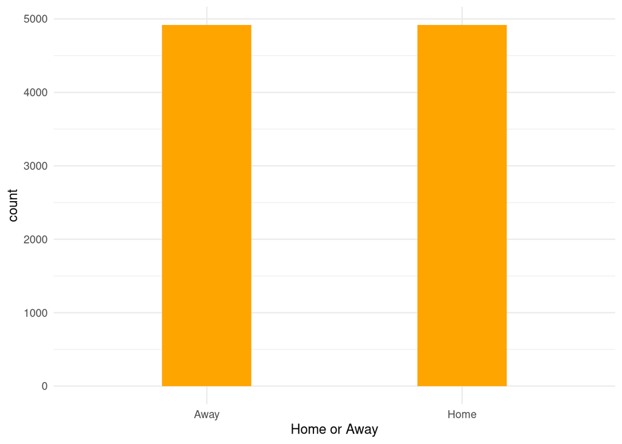

```r
ggplot(df) +
  geom_bar(aes(x=Home), width = 0.35,fill="orange") +
  xlab("Home or Away")+
  theme_minimal()
```

### Result

From the diagram, we can see that in the dataset there are an equal amount of Home and Away games played.

### Comparing two teams, GSW vs. LAL

On the other hand, we can compare what were the win or loss statistics in the span of these games. We will take Golden State Warriors and Los Angeles Lakers for example.

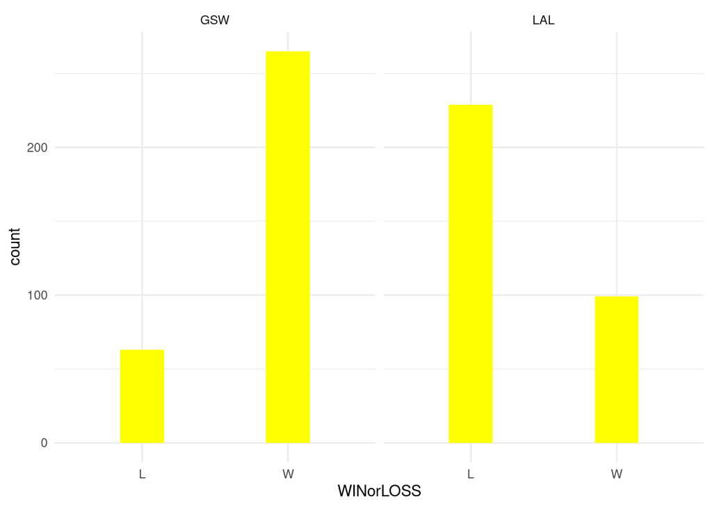

```r
Wins <- df %>%
  select(Team, WINorLOSS) %>%
  dplyr::filter(Team=="GSW") %>%
  rbind(
    df %>%
      select(Team, WINorLOSS) %>%
      dplyr::filter(Team=="LAL")
  )

ggplot(Wins) +
  geom_bar(aes(x=WINorLOSS), width = 0.3, fill="yellow") +
  facet_grid(. ~Team) +
  theme_minimal()
```

#### Results

In these diagrams, it is clear that Golden State Warriors had a few great regular seasons, while Los Angeles Lakers probably did not manage to compete further in play-offs. We could also calculate the win/lose percentage for these teams :

```r
WinsGSW <- df %>%
  dplyr::filter(Team=="GSW")

WinsGSW %>%
  dplyr::filter(WINorLOSS=="W") %>%
  summarise(WinPercentage=n()/dim(WinsGSW)[1] * 100) %>%
  cbind(
    WinsGSW %>%
      dplyr::filter(WINorLOSS=="L") %>%
      summarise(LosePercentage=n()/dim(WinsGSW)[1] * 100)
  )
```

```
##   WinPercentage LosePercentage
## 1      80.79268       19.20732
```

```r
WinsLAL <- df %>%
  dplyr::filter(Team=="LAL")

WinsLAL %>%
  dplyr::filter(WINorLOSS=="W") %>%
  summarise(WinPercentage=n()/dim(WinsLAL)[1] * 100) %>%
  cbind(
    WinsLAL %>%
      dplyr::filter(WINorLOSS=="L") %>%
      summarise(LosePercentage=n()/dim(WinsLAL)[1] * 100)
  )
```

```
##   WinPercentage LosePercentage
## 1      30.18293       69.81707
```

## Win or Loss impacts

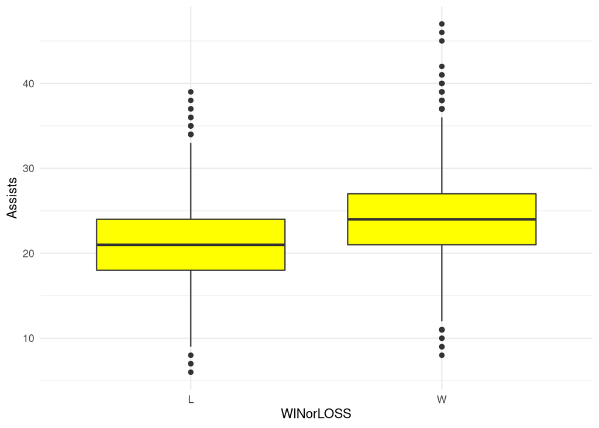

```r
ggplot(df) +
  geom_boxplot(aes(x=WINorLOSS,y=Assists), fill="yellow") +
  theme_minimal()
```

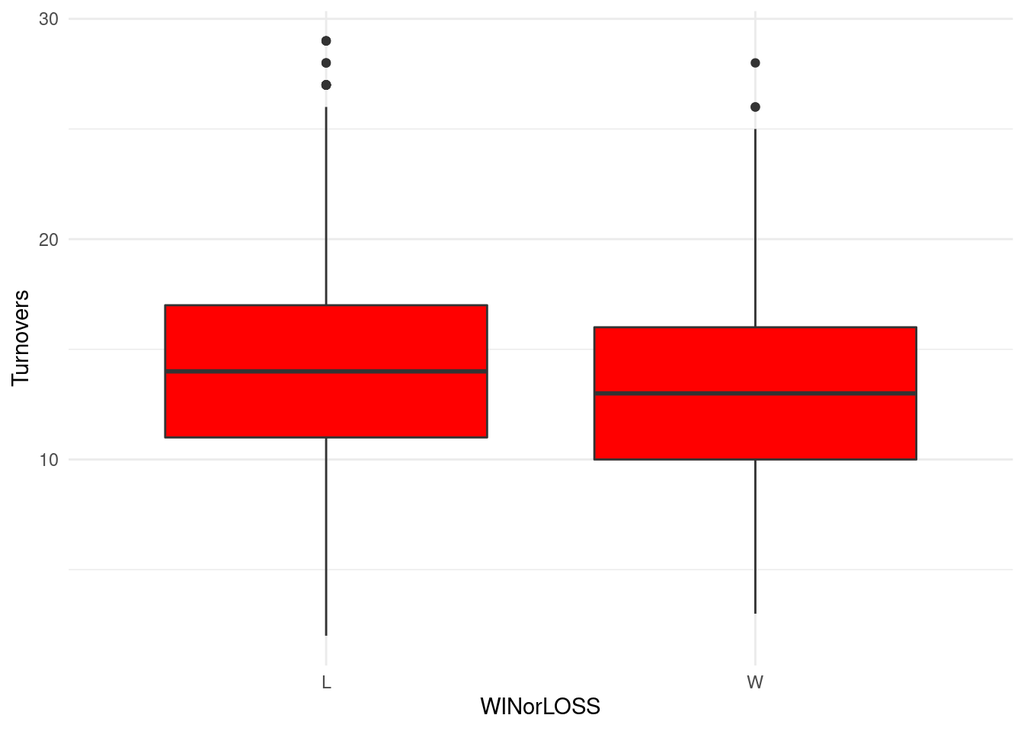

```r
ggplot(df) +
  geom_boxplot(aes(x=WINorLOSS,y=Turnovers), fill="red") +
  theme_minimal()
```

### Results

As we have expected, Assists have a great impact on whether the game will be won, and on the boxplot we can see what are the minimum, maximum, median of assists in games and how they impact the outcome of the game. The same goes for Turnovers, but they impact the losses since it represents the times the team lost the possession.

## Correlation between Team points and Field goals

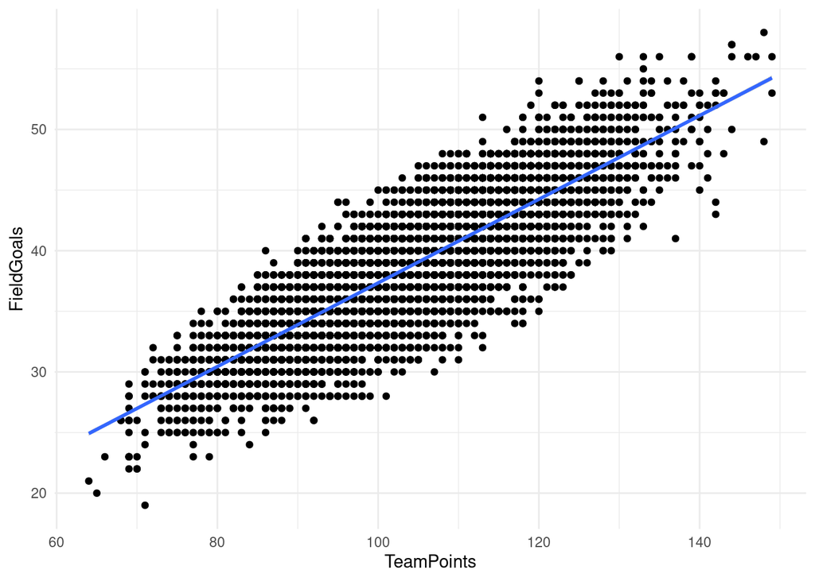

```r
model <- lm(df$TeamPoints~df$FieldGoals)

ggplot() +
  geom_point(data = df, aes(x=TeamPoints,y=FieldGoals)) +
  geom_smooth(method = lm, data = df, aes(x=TeamPoints,y=FieldGoals)) +
  theme_minimal()
```

### Results

On this scatterplot, we can see how the field goals scored impact the total points of the team and the overall outcome. Apart from field goals we also have to take free throws into consideration as the games with a lot of fouls can be a great impact on the game.

# Visualization of the data

## Home court advantage

In this section, we are going to focus on the quantity of the games that are won by the teams, on the home or away court.

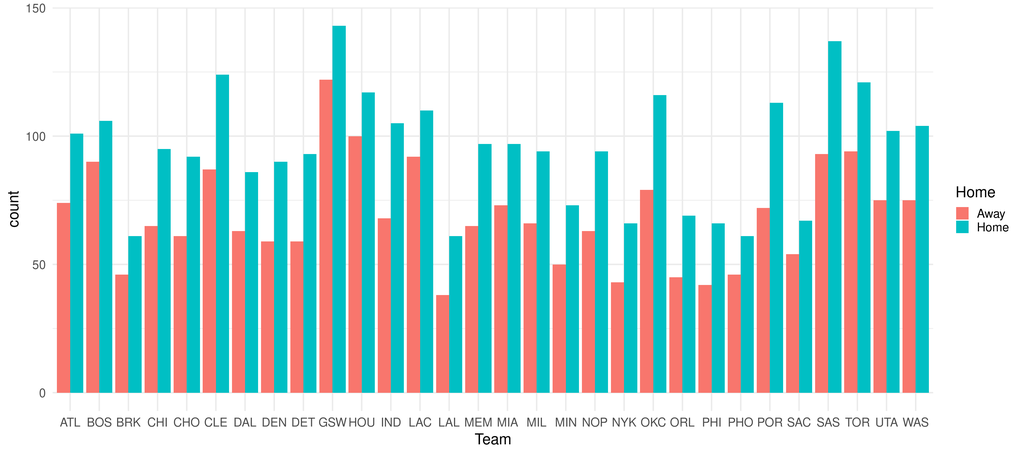

```r
HomeWins <- df %>%
  dplyr::filter(WINorLOSS=="W")

ggplot(HomeWins) +
  geom_bar(aes(x=Team, fill=Home), position = position_dodge(preserve = 'single')) +
  theme_minimal(base_size = 19)
```

### Results

Usually, home-court advantage is considered a big factor in winning games. Even though a lot of teams can surprise and lose at the home arena, it is more probable that the home team will win the game. From the graph, we can see that no team has succeeded to have more wins at away games than at home games in the period of 2014-2018. Some of the teams were closer than the others, for instance, Sacramento Kings, but there are also teams that are winning much more games at home court, for instance, Oklahoma City Thunder.

## Offensive rebound percentage

Offensive rebound is a term when a team gathers a possession even after a missed field goal. The aim is to find each teams’ percentage of offensive rebounds per game.

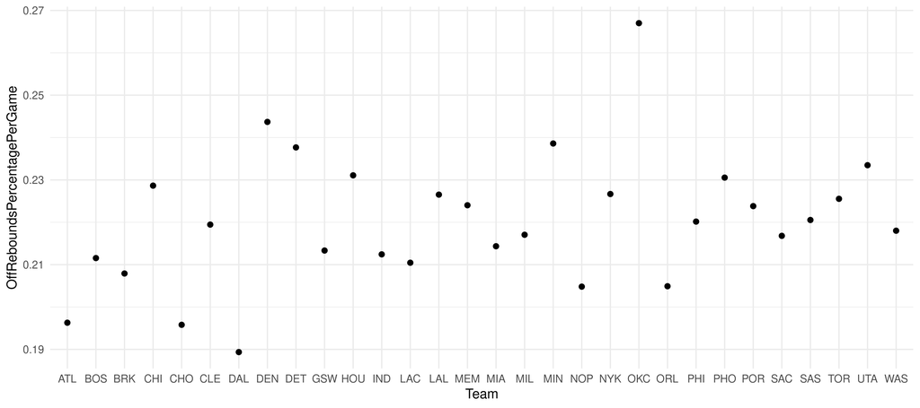

```r
OffReboundsPerc <- df %>%
  mutate(FieldGoalsMissed=FieldGoalsAttempted-FieldGoals) %>%
  select(Team, FieldGoalsMissed, OffRebounds) %>%
  mutate(OffReboundsPercentage=OffRebounds/FieldGoalsMissed) %>%
  group_by(Team) %>%
  summarise(OffReboundsPercentagePerGame=mean(OffReboundsPercentage)) %>%
  arrange(desc(OffReboundsPercentagePerGame))


ggplot(OffReboundsPerc) +
  geom_point(aes(x=Team,y=OffReboundsPercentagePerGame), size=3.5) +
  theme_minimal(base_size = 19)
```

### Result

For offensive rebound percentage, we had to first calculate how many missed shots we have, then find the ratio between Offensive rebounds and Missed shots. As a result, we hot the Offensive Rebound percentage per game, and the winner by far was Oklahoma City Thunder with almost 27 % of offensive rebounds after a missed shot, and the Dallas Mavericks as a team with least offensive rebounds per game with 19 %.

## Difference between scores

This analysis is just the frequency of the differences between the score of the winning and the opposing team.

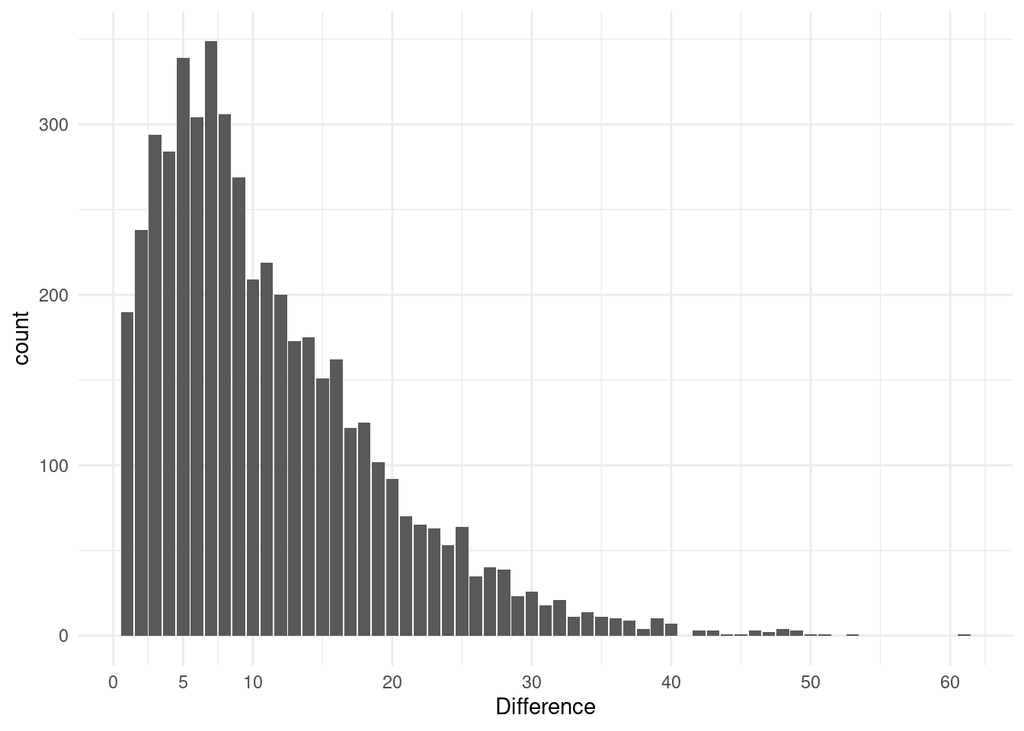

```r
Blowout <- df %>%
  select(Team, Opponent, TeamPoints, OpponentPoints, WINorLOSS) %>%
  dplyr::filter(WINorLOSS == "W") %>%
  mutate(Difference = TeamPoints-OpponentPoints)

ggplot(Blowout) +
  geom_bar(aes(Difference)) +
  scale_x_continuous(breaks = c(0,5,10,20,30,40,50,60)) +
  theme_minimal()
```

### Results

In the diagram above, we can see the frequencies of final score differences, with 7 being the most frequent, and 61 being the biggest difference between scores which is at the same time the 6th greatest difference in NBA history, and it was between Charlotte Hornets and Memphis Grizzlies.

## Three points attempts per game

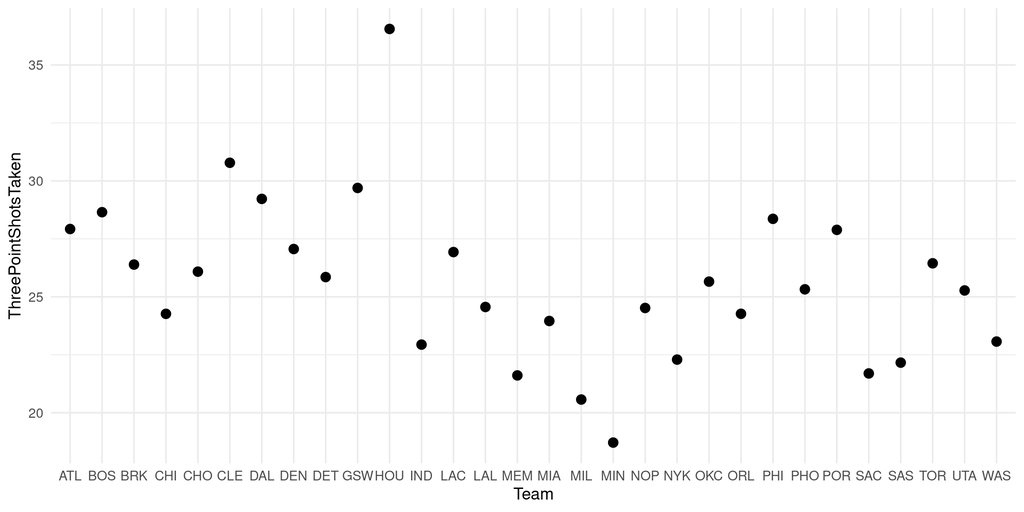

```r
ThreePointShots <- df %>%
  group_by(Team) %>%
  summarise(ThreePointShotsTaken = mean(X3PointShotsAttempted)) %>%
  arrange(desc(ThreePointShotsTaken))

ggplot(ThreePointShots) +
  geom_point(mapping=aes(x=Team, y=ThreePointShotsTaken), size=3.5)+
  theme_minimal(base_size = 14)
```

### Results

This diagram shows what is the average three-point attempts per game for each team. As the result, we can see Houston Rockets being the leaders and Minnesota Timberwolves as the team with the least three-point attempts per game.

# Conclusion

In conclusion, we can see how some of these statistics impact the game score, and we have succeeded to show how home games are much more likely to be won, what are the usual differences in scores, and the amount of three-point shots that are taken by each team. Since this is a large dataset, we can perform a lot of other analytics, but what would be even more interesting is to have the data for the statistics from a certain player in the team. However, we can leave that for another time.

# References

Tóth, Attila. 2019. “Extracting and Analyzing 1000 Basketball Games Using Pandas and Chartify.” https://www.analyticsvidhya.com/blog/2019/05/scraping-nba-data-analyze-1000-basketball-games-python/.

Wikipedia. 2021. “Exploratory Data Analysis.” https://en.wikipedia.org/wiki/Exploratory_data_analysis.